# FM Data Visualization

Sara

May 15, 2018

#### Necessary libraries were loaded.

```r
library(plyr)
library(dplyr)
library(ggplot2)
library(ggpubr)
library(plotly)
library(reshape2)
library(tidyr)
library(tinytex)
```

#### The working directory was set and the cleaned data loaded.

```r
setwd("C:/Users/saraa/Desktop")
fmdata <- read.csv("fe_local_clean.csv")
```

#### A function “percent” was added to convert calculations to percentages.

```r
percent <- function(x, digits = 2, format = "f", ...) {
  paste0(formatC(100 * x, format = format, digits = digits, ...), "%")
}
```

### A data frame, “moremkts” was created from the original data frame “fmdata” for comparison.

```r
moremkts <- fmdata[fmdata$Increased == "1",]
```

#### What percentage of counties saw an increase in farmer’s markets per 1,000 people from 2009 to 2016?

```r
proportion_more <- nrow(moremkts)/nrow(fmdata)
percent(proportion_more)
```

```
## [1] "51.89%"
```

#### What percentage of these counties sell all food types?

```r
allfoods <- data.frame(moremkts$Sells_Produce, moremkts$Sells_Animal, moremkts$Sells_Baked, moremkts$Sells_OtherFood)
count_allfoods <- allfoods[rowSums(allfoods == 0) < 1, ]
allfoods <- nrow(count_allfoods)/nrow(moremkts)
percent(allfoods)
```

```
## [1] "73.57%"
```

#### What percentage of all counties sell all types of food products?

```r
allfoods_all <- data.frame(fmdata$Sells_Produce, fmdata$Sells_Animal, fmdata$Sells_Baked, fmdata$Sells_OtherFood)
count_allfoods_all <- allfoods_all[rowSums(allfoods_all == 0) < 1, ]
allfoods_all <- nrow(count_allfoods_all)/nrow(fmdata)
percent(allfoods_all)
```

```
## [1] "48.97%"
```

#### What percentage of these counties accept all noncash methods of payment?

```r
noncash <- data.frame(moremkts$CreditCards, moremkts$Accepts_SNAP, moremkts$Accepts_WIC, moremkts$Accepts_WICCash,
                      moremkts$Accepts_Senior)
count_noncash <- noncash[rowSums(noncash == 0) < 1, ]
noncash <- nrow(count_noncash)/nrow(moremkts)
percent(noncash)
```

```
## [1] "17.72%"
```

#### What percentage of all counties accept all noncash payments?

```r
noncash_all <- data.frame(fmdata$CreditCards, fmdata$Accepts_SNAP, fmdata$Accepts_WIC, fmdata$Accepts_WICCash,
                          fmdata$Accepts_Senior)
count_noncash_all <- noncash_all[rowSums(noncash_all == 0) < 1, ]
noncash_all <- nrow(count_noncash_all)/nrow(fmdata)
percent(noncash_all)
```

```
## [1] "11.10%"
```

#### What percentage of counties that saw increases are in the Midwest?

```r
MoreMktMidwest <- data.frame(moremkts$Illinois, moremkts$Indiana, moremkts$Iowa, moremkts$Kansas, moremkts$Michigan, moremkts$Minnesota, moremkts$Missouri, moremkts$Nebraska, moremkts$NorthDakota, moremkts$Ohio, moremkts$SouthDakota, moremkts$Wisconsin)
count_midwest <- MoreMktMidwest[rowSums(MoreMktMidwest == 1), ]
midwest <- nrow(count_midwest)/nrow(moremkts)
percent(midwest)
```

```
## [1] "35.25%"
```

#### What percentage of all counties are in the Midwest?

```r
MktMidwest <- data.frame(fmdata$Illinois, fmdata$Indiana, fmdata$Iowa, fmdata$Kansas, fmdata$Michigan, fmdata$Minnesota, fmdata$Missouri, fmdata$Nebraska, fmdata$NorthDakota, fmdata$Ohio, fmdata$SouthDakota, fmdata$Wisconsin)
count_midwest <- MktMidwest[rowSums(MktMidwest == 1), ]
midwest <- nrow(count_midwest)/nrow(fmdata)
percent(midwest)
```

```
## [1] "33.57%"
```

#### What percentage of counties that saw increases are in the Northeast?

```r
MoreMktNortheast <- data.frame(moremkts$Connecticut, moremkts$Delaware, moremkts$DistrictofColumbia, moremkts$Maine, moremkts$Maryland, moremkts$Massachusetts, moremkts$NewHampshire, moremkts$NewJersey, moremkts$NewYork, moremkts$Pennsylvania, moremkts$RhodeIsland, moremkts$Vermont)
count_northeast <- MoreMktNortheast[rowSums(MoreMktNortheast == 1), ]
northeast <- nrow(count_northeast)/nrow(moremkts)
percent(northeast)
```

```
## [1] "11.83%"
```

#### What percentage of all counties are in the Northeast?

```r
MktNortheast <- data.frame(fmdata$Connecticut, fmdata$Delaware, fmdata$DistrictofColumbia, fmdata$Maine, fmdata$Maryland, fmdata$Massachusetts, fmdata$NewHampshire, fmdata$NewJersey, fmdata$NewYork, fmdata$Pennsylvania, fmdata$RhodeIsland, fmdata$Vermont)
count_northeast <- MktNortheast[rowSums(MktNortheast == 1), ]
northeast <- nrow(count_northeast)/nrow(fmdata)
percent(northeast)
```

```
## [1] "7.80%"
```

#### What percentage of counties that saw increases are in the South?

```r
MoreMktSouth <- data.frame(moremkts$Alabama, moremkts$Arkansas, moremkts$Florida, moremkts$Georgia, moremkts$Kentucky, moremkts$Louisiana, moremkts$Mississippi, moremkts$NorthCarolina, moremkts$Oklahoma, moremkts$SouthCarolina, moremkts$Tennessee, moremkts$Texas, moremkts$Virginia, moremkts$WestVirginia)
count_south <- MoreMktSouth[rowSums(MoreMktSouth == 1), ]
south <- nrow(count_south)/nrow(moremkts)
percent(south)
```

```
## [1] "38.75%"
```

#### What percentage of all counties are in the South?

```r
MktSouth <- data.frame(fmdata$Alabama, fmdata$Arkansas, fmdata$Florida, fmdata$Georgia, fmdata$Kentucky, fmdata$Louisiana, fmdata$Mississippi, fmdata$NorthCarolina, fmdata$Oklahoma, fmdata$SouthCarolina, fmdata$Tennessee, fmdata$Texas, fmdata$Virginia, fmdata$WestVirginia)
count_south <- MktSouth[rowSums(MktSouth == 1), ]
south <- nrow(count_south)/nrow(fmdata)
percent(south)
```

```
## [1] "44.38%"
```

#### What percentage of counties that saw increases are in the West?

```r
MoreMktWest <- data.frame(moremkts$Alaska, moremkts$Arizona, moremkts$California, moremkts$Colorado, moremkts$Hawaii, moremkts$Idaho, moremkts$Montana, moremkts$Nevada, moremkts$NewMexico, moremkts$Oregon, moremkts$Utah, moremkts$Washington, moremkts$Wyoming)
count_west <- MoreMktWest[rowSums(MoreMktWest == 1), ]
west <- nrow(count_west)/nrow(moremkts)
percent(west)
```

```
## [1] "14.16%"
```

#### What percentage of all counties are in the West?

```r
MktWest <- data.frame(fmdata$Alaska, fmdata$Arizona, fmdata$California, fmdata$Colorado, fmdata$Hawaii, fmdata$Idaho, fmdata$Montana, fmdata$Nevada, fmdata$NewMexico, fmdata$Oregon, fmdata$Utah, fmdata$Washington, fmdata$Wyoming)
count_west <- MktWest[rowSums(MktWest == 1), ]
west <- nrow(count_west)/nrow(fmdata)
percent(west)
```

```
## [1] "14.25%"
```

#### From these calculations, the Midwest looks slightly overrepresented in counties that saw an increase in markets, the Northeast overrepresented, the South underrepresented, and the West slightly underrepresented.

#### Histograms

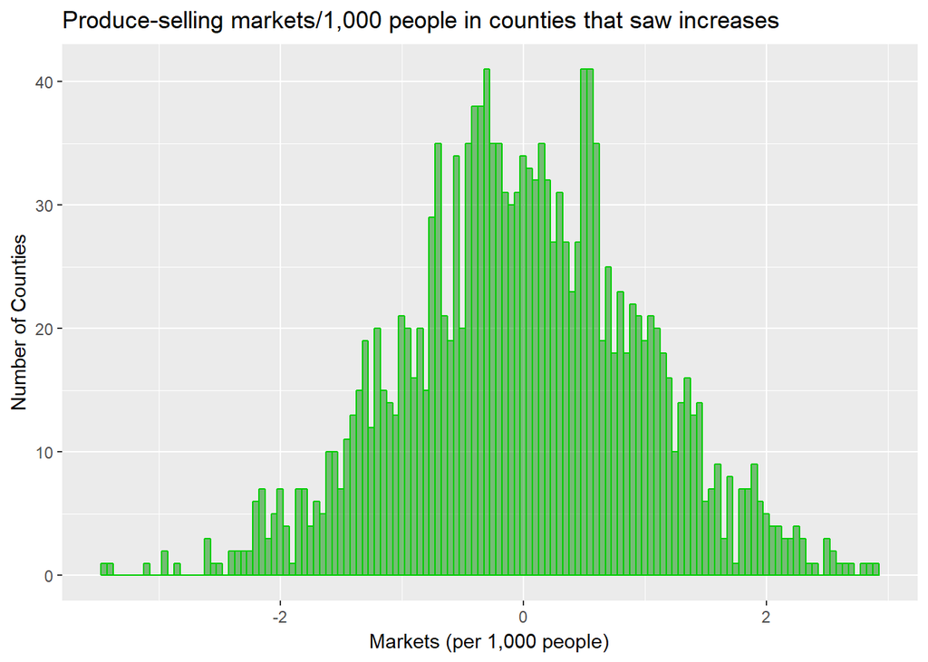

```r
ggplot (moremkts, aes(Produce_norm)) +
  geom_histogram(binwidth = 0.05,col="green3",fill="green4",alpha = .5)+
  ggtitle("Produce-selling markets/1,000 people in counties that saw increases")+
  scale_x_continuous(name="Markets (per 1,000 people)")+
  scale_y_continuous(name="Number of Counties")
```

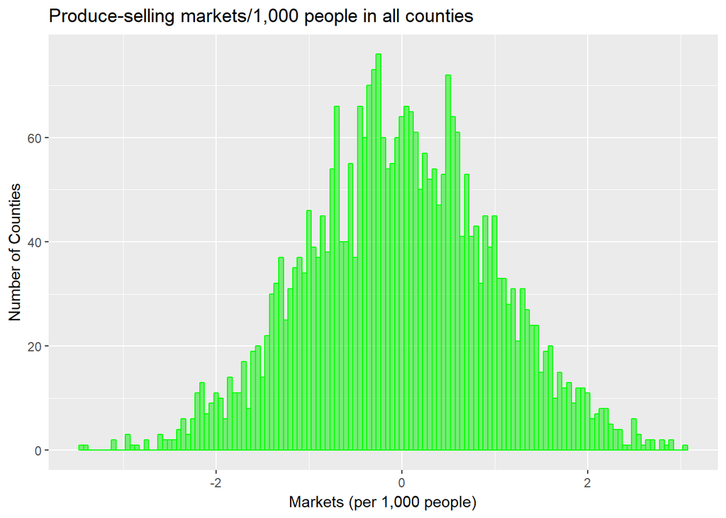

```r
ggplot (fmdata, aes(Produce_norm)) +
  geom_histogram(binwidth = 0.05,col="green1",fill="green2",alpha = .5)+
  ggtitle("Produce-selling markets/1,000 people in all counties")+
  scale_x_continuous(name="Markets (per 1,000 people)")+
  scale_y_continuous(name="Number of Counties")
```

#### Comparing markets that sell produce in counties that saw an increase in farmer’s markets with markets in all counties. The means look similar.

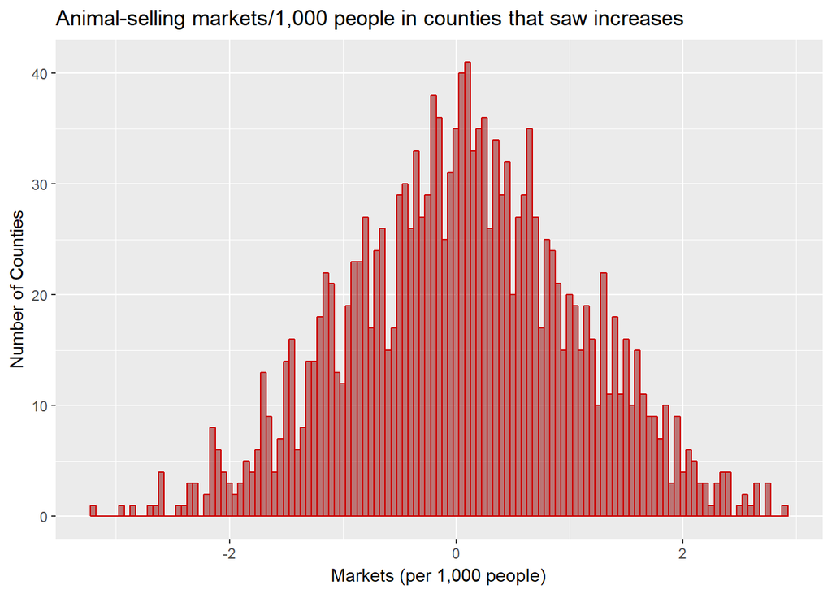

```r
ggplot (moremkts, aes(Animal_norm)) +
  geom_histogram(binwidth = 0.05,col="red3",fill="red4",alpha = .5)+
  ggtitle("Animal-selling markets/1,000 people in counties that saw increases")+
  scale_x_continuous(name="Markets (per 1,000 people)")+
  scale_y_continuous(name="Number of Counties")
```

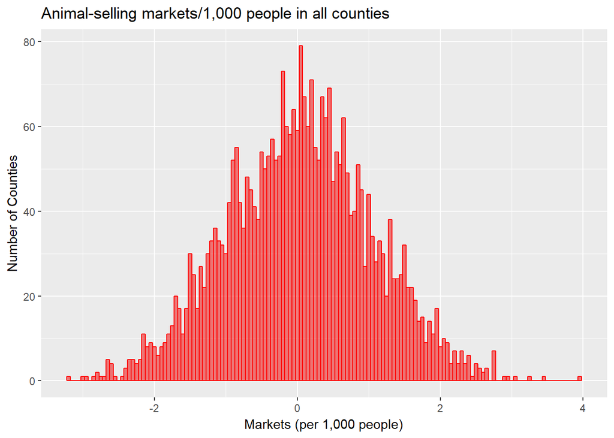

```r
ggplot (fmdata, aes(Animal_norm)) +
  geom_histogram(binwidth = 0.05,col="red1",fill="red2",alpha = .5)+
  ggtitle("Animal-selling markets/1,000 people in all counties")+
  scale_x_continuous(name="Markets (per 1,000 people)")+
  scale_y_continuous(name="Number of Counties")
```

#### Comparing markets that sell animal products in counties that saw an increase in farmer’s markets with markets in all counties. The mean of the “increase” histogram looks slightly higher than the “overall” histogram.

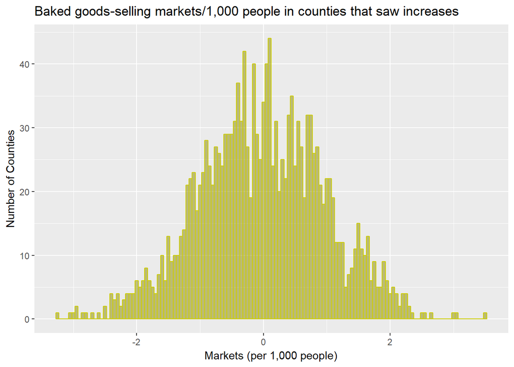

```r
ggplot (moremkts, aes(Baked_norm)) +
  geom_histogram(binwidth = 0.05,col="yellow3",fill="yellow4",alpha = .5)+
  ggtitle("Baked goods-selling markets/1,000 people in counties that saw increases")+
  scale_x_continuous(name="Markets (per 1,000 people)")+
  scale_y_continuous(name="Number of Counties")
```

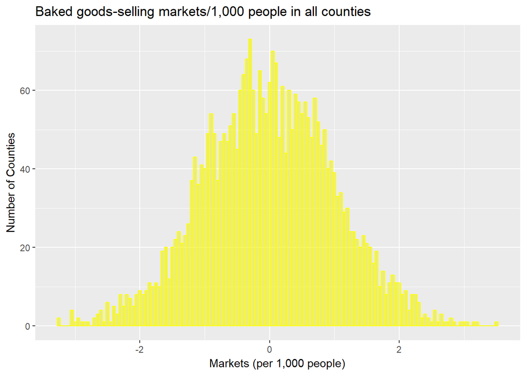

```r
ggplot (fmdata, aes(Baked_norm)) +
  geom_histogram(binwidth = 0.05,col="yellow1",fill="yellow2",alpha = .5)+
  ggtitle("Baked goods-selling markets/1,000 people in all counties")+
  scale_x_continuous(name="Markets (per 1,000 people)")+
  scale_y_continuous(name="Number of Counties")
```

#### Comparing markets that sell baked goods in counties that saw an increase in farmer’s markets with markets in all counties. The mean of the “increase” histogram looks slightly higher than the “overall” histogram.

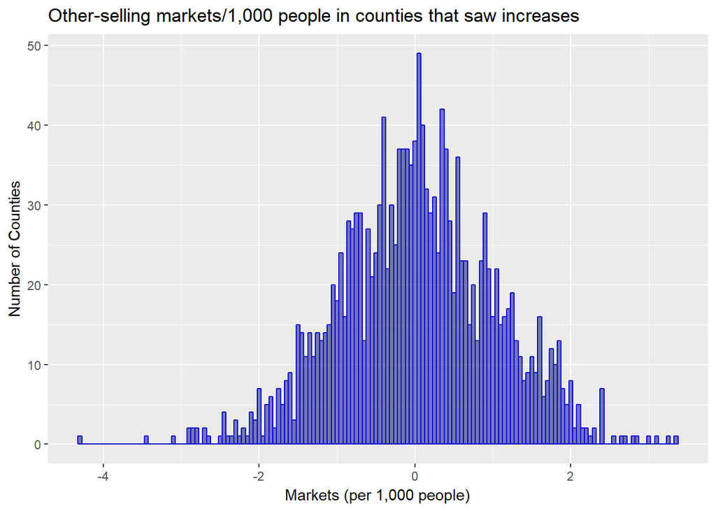

```r
ggplot (moremkts, aes(OtherFood_norm)) +
  geom_histogram(binwidth = 0.05,col="blue3",fill="blue4",alpha = .5)+
  ggtitle("Other-selling markets/1,000 people in counties that saw increases")+
  scale_x_continuous(name="Markets (per 1,000 people)")+
  scale_y_continuous(name="Number of Counties")
```

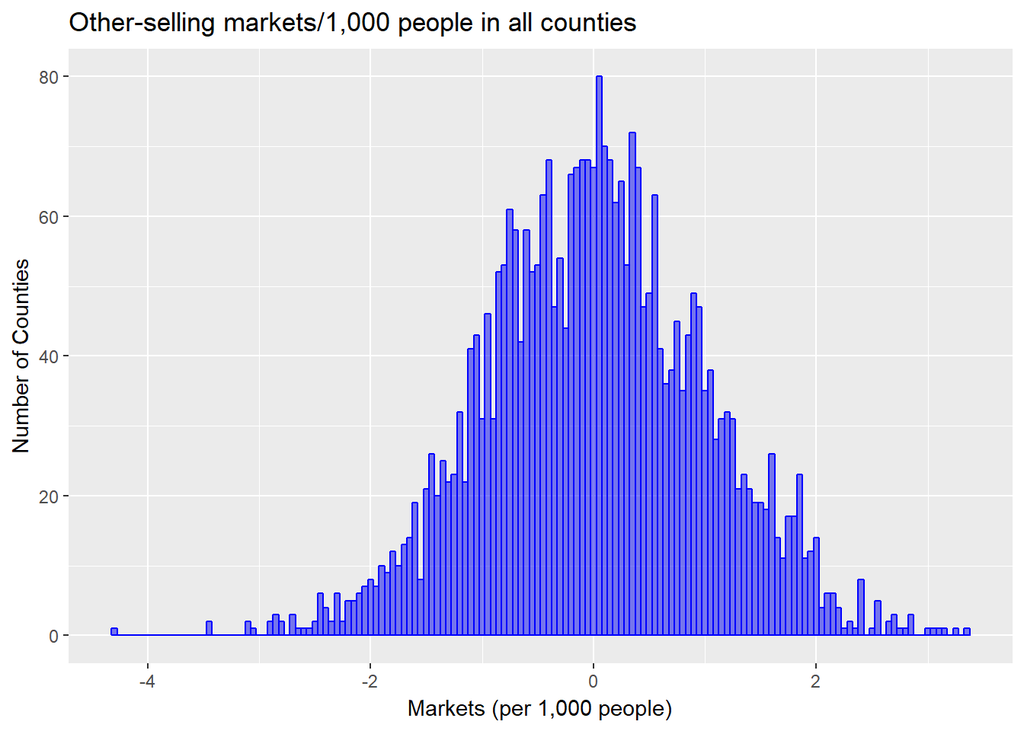

```r
ggplot (fmdata, aes(OtherFood_norm)) +
  geom_histogram(binwidth = 0.05,col="blue1",fill="blue2",alpha = .5)+
  ggtitle("Other-selling markets/1,000 people in all counties")+
  scale_x_continuous(name="Markets (per 1,000 people)")+
  scale_y_continuous(name="Number of Counties")
```

#### Comparing markets that sell other food products in counties that saw an increase in farmer’s markets with markets in all counties. The mean of the “increase” histogram looks slightly higher than the “overall” histogram.

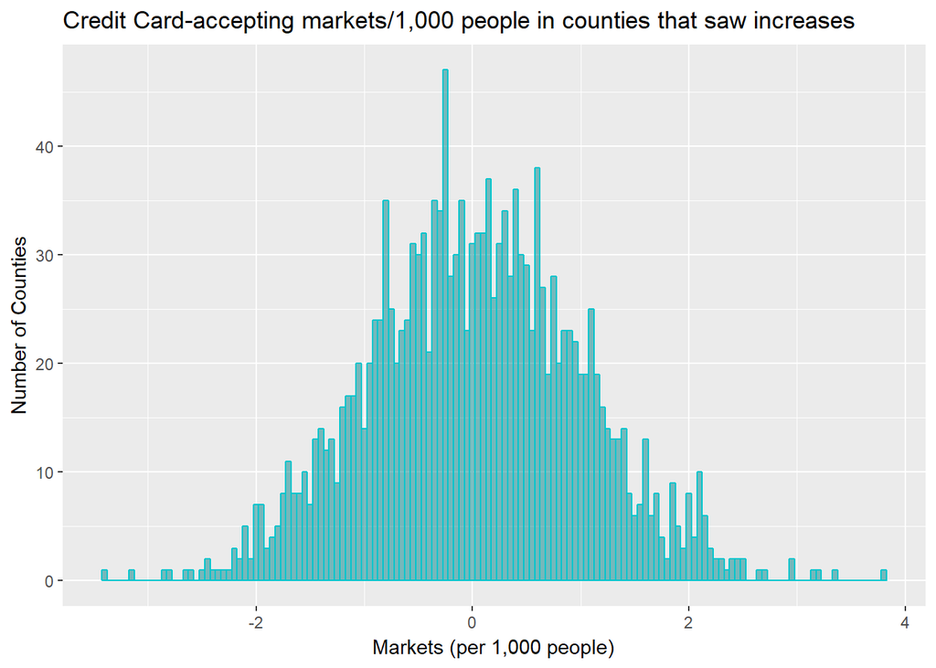

```r
ggplot (moremkts, aes(CreditCards_norm)) +
  geom_histogram(binwidth = 0.05,col="turquoise3",fill="turquoise4",alpha = .5)+
  ggtitle("Credit Card-accepting markets/1,000 people in counties that saw increases")+
  scale_x_continuous(name="Markets (per 1,000 people)")+
  scale_y_continuous(name="Number of Counties")
```

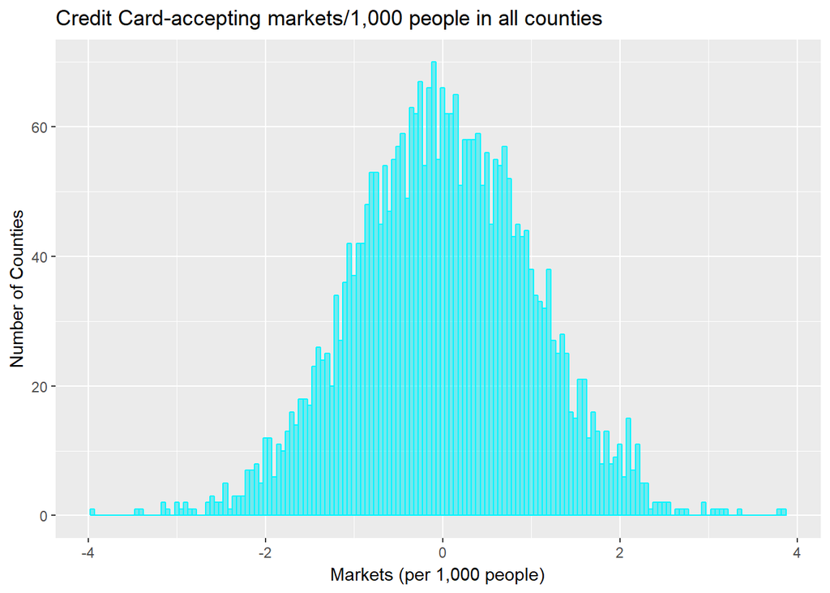

```r
ggplot (fmdata, aes(CreditCards_norm)) +
  geom_histogram(binwidth = 0.05,col="turquoise1",fill="turquoise2",alpha = .5)+
  ggtitle("Credit Card-accepting markets/1,000 people in all counties")+
  scale_x_continuous(name="Markets (per 1,000 people)")+
  scale_y_continuous(name="Number of Counties")
```

#### Comparing markets that accept credit cards in counties that saw an increase in farmer’s markets with markets in all counties. The mean of the “increase” histogram looks slightly higher than the “overall” histogram.

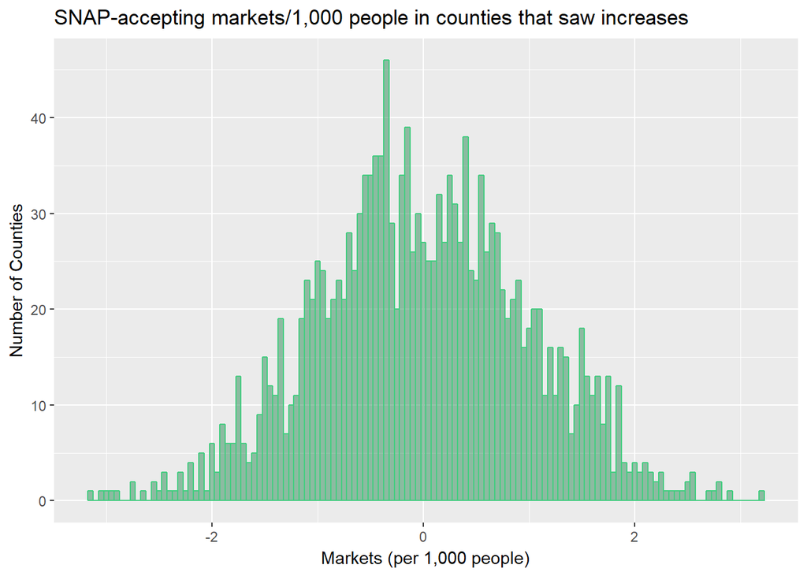

```r
ggplot (moremkts, aes(SNAP_norm)) +
  geom_histogram(binwidth = 0.05,col="seagreen3",fill="seagreen4",alpha = .5)+
  ggtitle("SNAP-accepting markets/1,000 people in counties that saw increases")+
  scale_x_continuous(name="Markets (per 1,000 people)")+
  scale_y_continuous(name="Number of Counties")
```

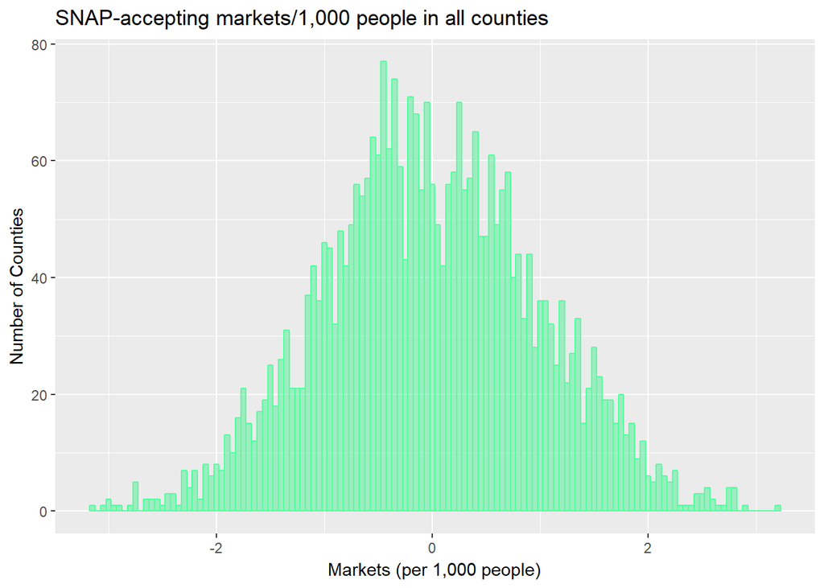

```r
ggplot (fmdata, aes(SNAP_norm)) +
  geom_histogram(binwidth = 0.05,col="seagreen1",fill="seagreen2",alpha = .5)+
  ggtitle("SNAP-accepting markets/1,000 people in all counties")+
  scale_x_continuous(name="Markets (per 1,000 people)")+
  scale_y_continuous(name="Number of Counties")
```

#### Comparing markets that accept SNAP in counties that saw an increase in farmer’s markets with markets in all counties. The means look similar.

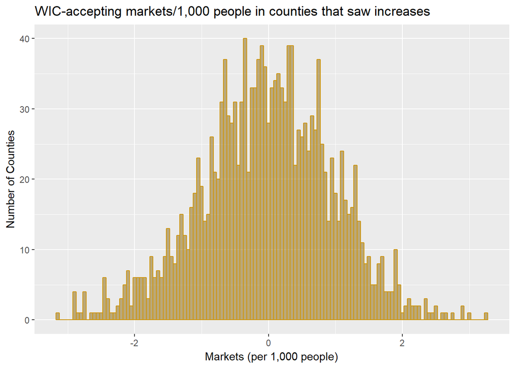

```r
ggplot (moremkts, aes(WIC_norm)) +
  geom_histogram(binwidth = 0.05,col="darkgoldenrod3",fill="darkgoldenrod4",alpha = .5)+
  ggtitle("WIC-accepting markets/1,000 people in counties that saw increases")+
  scale_x_continuous(name="Markets (per 1,000 people)")+
  scale_y_continuous(name="Number of Counties")
```

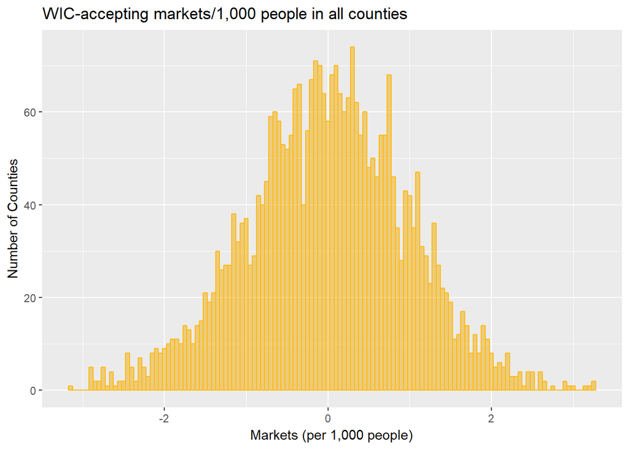

```r
ggplot (fmdata, aes(WIC_norm)) +
  geom_histogram(binwidth = 0.05,col="darkgoldenrod1",fill="darkgoldenrod2",alpha = .5)+
  ggtitle("WIC-accepting markets/1,000 people in all counties")+
  scale_x_continuous(name="Markets (per 1,000 people)")+
  scale_y_continuous(name="Number of Counties")
```

#### Comparing markets that accept WIC in counties that saw an increase in farmer’s markets with markets in all counties. The means look similar.

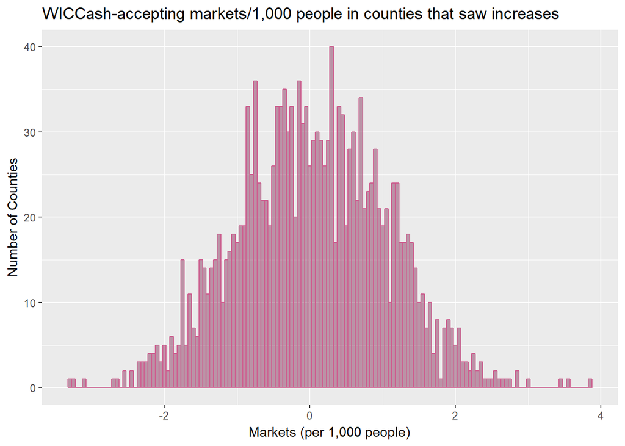

```r
ggplot (moremkts, aes(WICCash_norm)) +
  geom_histogram(binwidth = 0.05,col="hotpink3",fill="hotpink4",alpha = .5)+
  ggtitle("WICCash-accepting markets/1,000 people in counties that saw increases")+
  scale_x_continuous(name="Markets (per 1,000 people)")+
  scale_y_continuous(name="Number of Counties")
```

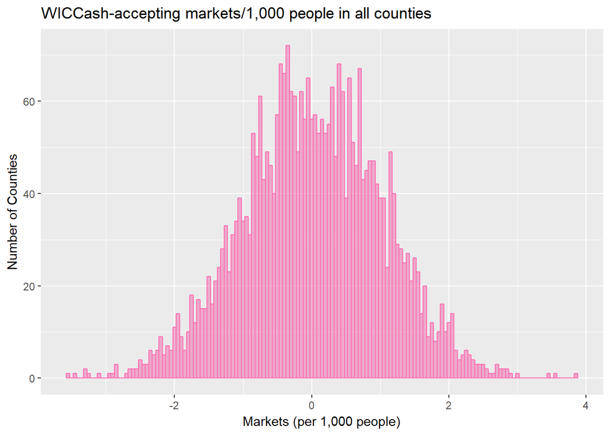

```r
ggplot (fmdata, aes(WICCash_norm)) +
  geom_histogram(binwidth = 0.05,col="hotpink1",fill="hotpink2",alpha = .5)+
  ggtitle("WICCash-accepting markets/1,000 people in all counties")+
  scale_x_continuous(name="Markets (per 1,000 people)")+
  scale_y_continuous(name="Number of Counties")
```

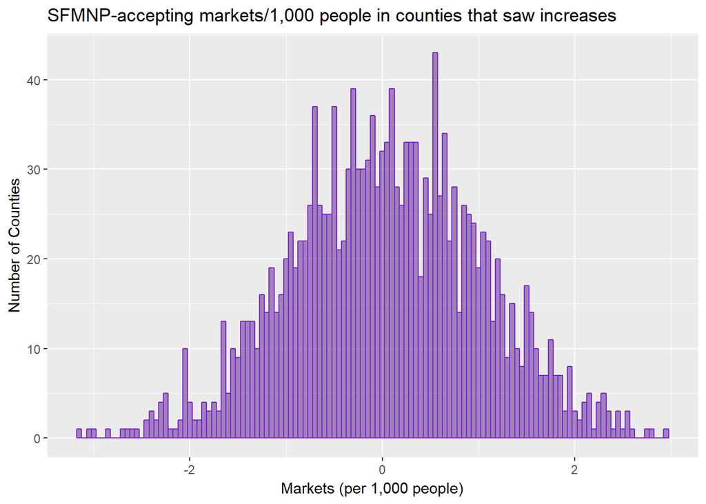

```r
ggplot (moremkts, aes(Senior_norm)) +
  geom_histogram(binwidth = 0.05,col="purple3",fill="purple4",alpha = .5)+
  ggtitle("SFMNP-accepting markets/1,000 people in counties that saw increases")+
  scale_x_continuous(name="Markets (per 1,000 people)")+
  scale_y_continuous(name="Number of Counties")
```

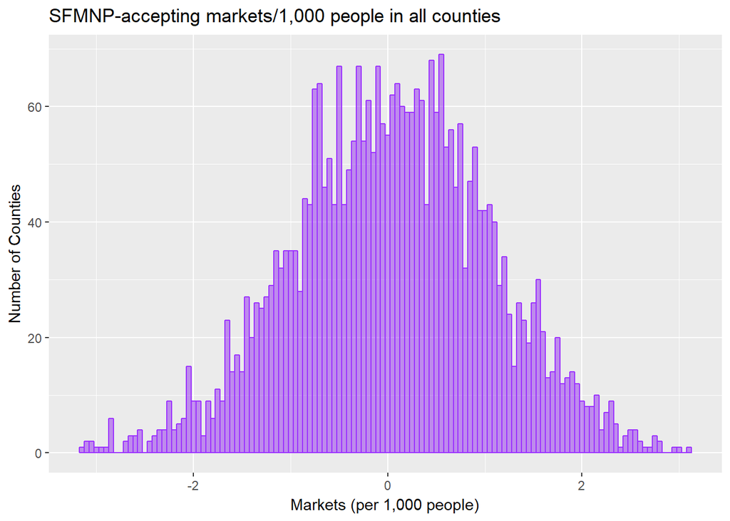

```r
ggplot (fmdata, aes(Senior_norm)) +
  geom_histogram(binwidth = 0.05,col="purple1",fill="purple2",alpha = .5)+
  ggtitle("SFMNP-accepting markets/1,000 people in all counties")+
  scale_x_continuous(name="Markets (per 1,000 people)")+
  scale_y_continuous(name="Number of Counties")
```

#### I will use the normalized data to compare the means between all counties and counties with more markets in 2016.

```r
t.test(moremkts$Produce_norm, fmdata$Produce_norm, alternative = "two.sided")
```

```
##
##  Welch Two Sample t-test
##
## data:  moremkts$Produce_norm and fmdata$Produce_norm
## t = 0.67669, df = 3342, p-value = 0.4987
## alternative hypothesis: true difference in means is not equal to 0
## 95 percent confidence interval:
##  -0.03885920  0.07981848
## sample estimates:
##    mean of x    mean of y
## -0.001752299 -0.022231944
```

```r
t.test(moremkts$Animal_norm, fmdata$Animal_norm, alternative = "two.sided")
```

```
##
##  Welch Two Sample t-test
##
## data:  moremkts$Animal_norm and fmdata$Animal_norm
## t = 0.82264, df = 3317, p-value = 0.4108
## alternative hypothesis: true difference in means is not equal to 0
## 95 percent confidence interval:
##  -0.03503556  0.08568652
## sample estimates:
##  mean of x  mean of y
## 0.06252115 0.03719567
```

```r
t.test(moremkts$Baked_norm, fmdata$Baked_norm, alternative = "two.sided")
```

```
##
##  Welch Two Sample t-test
##
## data:  moremkts$Baked_norm and fmdata$Baked_norm
## t = -0.51679, df = 3344.7, p-value = 0.6053
## alternative hypothesis: true difference in means is not equal to 0
## 95 percent confidence interval:
##  -0.07542238  0.04395679
## sample estimates:
##   mean of x   mean of y
## -0.02933476 -0.01360197
```

```r
t.test(moremkts$OtherFood_norm, fmdata$OtherFood_norm, alternative = "two.sided")
```

```
##
##  Welch Two Sample t-test
##
## data:  moremkts$OtherFood_norm and fmdata$OtherFood_norm
## t = 0.7074, df = 3267.9, p-value = 0.4794
## alternative hypothesis: true difference in means is not equal to 0
## 95 percent confidence interval:
##  -0.03814030  0.08119531
## sample estimates:
##   mean of x   mean of y
## 0.029849172 0.008321667
```

```r
t.test(moremkts$CreditCards_norm, fmdata$CreditCards_norm, alternative = "two.sided")
```

```
##
##  Welch Two Sample t-test
##
## data:  moremkts$CreditCards_norm and fmdata$CreditCards_norm
## t = 0.7434, df = 3328.5, p-value = 0.4573
## alternative hypothesis: true difference in means is not equal to 0
## 95 percent confidence interval:
##  -0.03683118  0.08181707
## sample estimates:
##   mean of x   mean of y
## 0.023871245 0.001378301
```

```r
t.test(moremkts$SNAP_norm, fmdata$SNAP_norm, alternative = "two.sided")
```

```
##
##  Welch Two Sample t-test
##
## data:  moremkts$SNAP_norm and fmdata$SNAP_norm
## t = 0.36371, df = 3282.4, p-value = 0.7161
## alternative hypothesis: true difference in means is not equal to 0
## 95 percent confidence interval:
##  -0.04859213  0.07072557
## sample estimates:
##    mean of x    mean of y
## -0.004535254 -0.015601973
```

```r
t.test(moremkts$WIC_norm, fmdata$WIC_norm, alternative = "two.sided")
```

```
##
##  Welch Two Sample t-test
##
## data:  moremkts$WIC_norm and fmdata$WIC_norm
## t = -0.6393, df = 3314.9, p-value = 0.5227
## alternative hypothesis: true difference in means is not equal to 0
## 95 percent confidence interval:
##  -0.07811748  0.03970143
## sample estimates:
##    mean of x    mean of y
## -0.023413243 -0.004205218
```

```r
t.test(moremkts$WICCash_norm, fmdata$WICCash_norm, alternative = "two.sided")
```

```
##
##  Welch Two Sample t-test
##
## data:  moremkts$WICCash_norm and fmdata$WICCash_norm
## t = 0.27163, df = 3279.2, p-value = 0.7859
## alternative hypothesis: true difference in means is not equal to 0
## 95 percent confidence interval:
##  -0.05251657  0.06940780
## sample estimates:
##  mean of x  mean of y
## 0.03137339 0.02292778
```

```r
t.test(moremkts$Senior_norm, fmdata$Senior_norm, alternative = "two.sided")
```

```
##
##  Welch Two Sample t-test
##
## data:  moremkts$Senior_norm and fmdata$Senior_norm
## t = 0.033677, df = 3358.9, p-value = 0.9731
## alternative hypothesis: true difference in means is not equal to 0
## 95 percent confidence interval:
##  -0.05859640  0.06064451
## sample estimates:
##  mean of x  mean of y
## 0.04144022 0.04041616
```

#### Independent-sample t-tests showed that the hypotheses of the difference in means being equal to zero for all types of markets is not rejected. There is no significant difference between the means of all types of the markets in counties that saw increases and the means of the markets in all counties.

## Linear Models

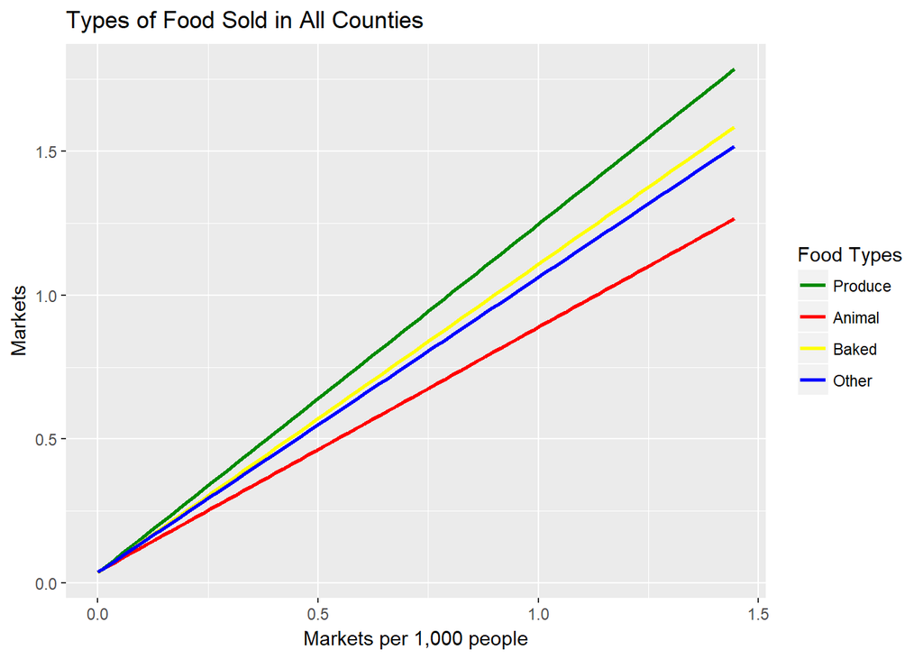

```r
MktTypes <- data.frame(fmdata$Markets2016, fmdata$Produce1000, fmdata$Animal1000, fmdata$Baked1000,
                       fmdata$OtherFood1000)

ggplot(MktTypes, aes(MktTypes$fmdata.Markets2016, y = Markets, color = MktTypes)) +
  geom_smooth(aes(y = fmdata.Produce1000, col = "Produce", fmdata.Markets2016), method ="lm", se = FALSE) +
  geom_smooth(aes(y = fmdata.Animal1000, col = "Animal", fmdata.Markets2016), method = "lm", se = FALSE) +
  geom_smooth(aes(y = fmdata.Baked1000, col = "Baked", fmdata.Markets2016), method = "lm", se = FALSE) +
  geom_smooth(aes(y = fmdata.OtherFood1000, col = "Other", fmdata.Markets2016), method = "lm", se = FALSE) +
  scale_color_manual("Food Types",
                     breaks = c("Produce", "Animal", "Baked", "Other"),
                     values = c("red", "yellow", "blue", "green4")) +
  ggtitle("Types of Food Sold in All Counties") +
  scale_x_continuous(name="Markets per 1,000 people")
```

#### Here are the different types of food sold in all counties. Interestingly, animal products have a weaker correlation with markets per 1,000.

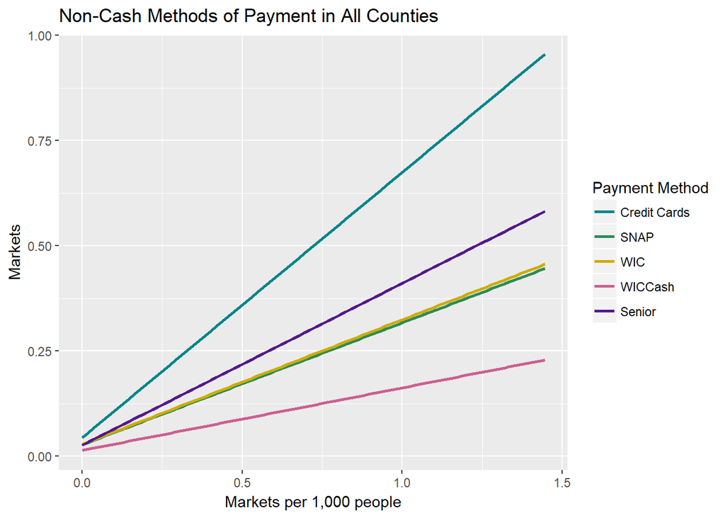

```r
PayTypes <- data.frame(fmdata$Markets2016, fmdata$CreditCards1000, fmdata$SNAP1000, fmdata$WIC1000,
                       fmdata$WICCash1000, fmdata$Senior1000)

ggplot(PayTypes, aes(PayTypes$fmdata.Markets2016, y = Markets, color = PayTypes)) +
  geom_smooth(aes(y = fmdata.CreditCards1000, col = "Credit Cards", fmdata.Markets2016), method = "lm", se = FALSE) +
  geom_smooth(aes(y = fmdata.SNAP1000, col = "SNAP", fmdata.Markets2016), method = "lm", se = FALSE) +
  geom_smooth(aes(y = fmdata.WIC1000, col = "WIC", fmdata.Markets2016), method = "lm", se = FALSE) +
  geom_smooth(aes(y = fmdata.WICCash1000, col = "WICCash", fmdata.Markets2016), method = "lm", se = FALSE) +
  geom_smooth(aes(y = fmdata.Senior1000, col = "Senior", fmdata.Markets2016), method = "lm", se = FALSE) +
  ggtitle("Non-Cash Methods of Payment in All Counties") +
  scale_color_manual("Payment Method",
                     breaks = c("Credit Cards", "SNAP", "WIC", "WICCash", "Senior"),
                     values = c("turquoise4", "purple4", "seagreen", "gold3", "hotpink3")) +
  scale_x_continuous(name="Markets per 1,000 people")
```

#### These are the non-cash methods of payment in all counties. WICCash’s correlation with overall markets is much lower due to being established later than the other government programs. Alo, it is interesting that the SNAP and WIC plots are the same.

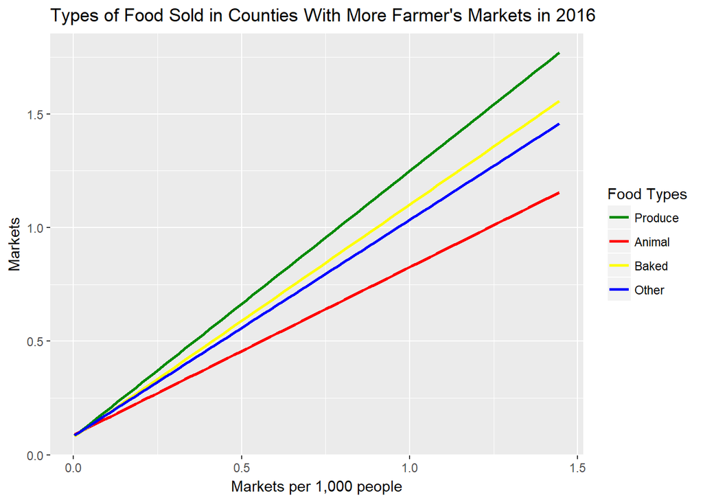

```r
MktTypesUp <- data.frame(moremkts$Markets2016, moremkts$Produce1000, moremkts$Animal1000, moremkts$Baked1000,
                         moremkts$OtherFood1000)

ggplot(MktTypesUp, aes(MktTypesUp$moremkts.Markets2016, y = Markets, color = MktTypesAll)) +
  geom_smooth(aes(y = moremkts.Produce1000, col = "Produce", moremkts.Markets2016), method = "lm", se = FALSE) +
  geom_smooth(aes(y = moremkts.Animal1000, col = "Animal", moremkts.Markets2016), method = "lm", se = FALSE) +
  geom_smooth(aes(y = moremkts.Baked1000, col = "Baked", moremkts.Markets2016), method = "lm", se = FALSE) +
  geom_smooth(aes(y = moremkts.OtherFood1000, col = "Other", moremkts.Markets2016), method = "lm", se = FALSE) +
  scale_color_manual("Food Types",
                     breaks = c("Produce", "Animal", "Baked", "Other"),
                     values = c("red", "yellow", "blue", "green4")) +
  ggtitle("Types of Food Sold in Counties With More Farmer's Markets in 2016") +
  scale_x_continuous(name="Markets per 1,000 people")
```

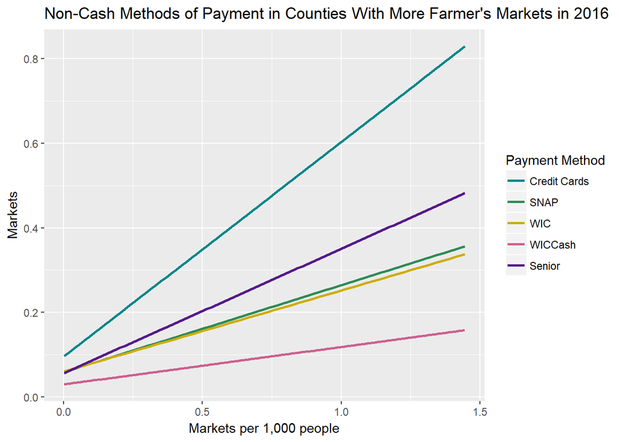

```r
PayTypesUp <- data.frame(moremkts$Markets2016, moremkts$CreditCards1000, moremkts$SNAP1000, moremkts$WIC1000,
                         moremkts$WICCash1000, moremkts$Senior1000)

ggplot(PayTypesUp, aes(PayTypesUp$moremkts.Markets2016, y = Markets, color = PayTypesAll)) +
  geom_smooth(aes(y = moremkts.CreditCards1000, col = "Credit Cards", moremkts.Markets2016), method = "lm", se = FALSE) +
  geom_smooth(aes(y = moremkts.SNAP1000, col = "SNAP", moremkts.Markets2016), method = "lm", se = FALSE) +
  geom_smooth(aes(y = moremkts.WIC1000, col = "WIC", moremkts.Markets2016), method = "lm", se = FALSE) +
  geom_smooth(aes(y = moremkts.WICCash1000, col = "WICCash", moremkts.Markets2016), method = "lm", se = FALSE) +
  geom_smooth(aes(y = moremkts.Senior1000, col = "Senior", moremkts.Markets2016), method = "lm", se = FALSE) +
  ggtitle("Non-Cash Methods of Payment in Counties With More Farmer's Markets in 2016") +
  scale_color_manual("Payment Method",
                     breaks = c("Credit Cards", "SNAP", "WIC", "WICCash", "Senior"),
                     values = c("turquoise4", "purple4", "seagreen", "gold3", "hotpink3")) +
  scale_x_continuous(name="Markets per 1,000 people")
```

### Geographical distribution

#### Here I will calculate the proportions of counties in each state that saw increases from 2009 to 2016, grouped by region (Midwest, Northeast, South; West).

```r
ALmore <- moremkts[moremkts$Alabama == "1",]
ALall <- fmdata[fmdata$Alabama == "1",]
proportion_AL_up <- nrow(ALmore)/nrow(ALall)

AKmore <- moremkts[moremkts$Alaska == "1",]
AKall <- fmdata[fmdata$Alaska == "1",]
proportion_AK_up <- nrow(AKmore)/nrow(AKall)

AZmore <- moremkts[moremkts$Arizona == "1",]
AZall <- fmdata[fmdata$Arizona == "1",]
proportion_AZ_up <- nrow(AZmore)/nrow(AZall)

ARmore <- moremkts[moremkts$Arkansas == "1",]
ARall <- fmdata[fmdata$Arkansas == "1",]
proportion_AR_up <- nrow(ARmore)/nrow(ARall)

CAmore <- moremkts[moremkts$California == "1",]
CAall <- fmdata[fmdata$California == "1",]
proportion_CA_up <- nrow(CAmore)/nrow(CAall)

COmore <- moremkts[moremkts$Colorado == "1",]
COall <- fmdata[fmdata$Colorado == "1",]
proportion_CO_up <- nrow(COmore)/nrow(COall)

CTmore <- moremkts[moremkts$Connecticut == "1",]
CTall <- fmdata[fmdata$Connecticut == "1",]
proportion_CT_up <- nrow(CTmore)/nrow(CTall)

DEmore <- moremkts[moremkts$Delaware == "1",]
DEall <- fmdata[fmdata$Delaware == "1",]
proportion_DE_up <- nrow(DEmore)/nrow(DEall)

DCmore <- moremkts[moremkts$DistrictofColumbia == "1",]
DCall <- fmdata[fmdata$DistrictofColumbia == "1",]
proportion_DC_up <- nrow(DCmore)/nrow(DCall)

FLmore <- moremkts[moremkts$Florida == "1",]
FLall <- fmdata[fmdata$Florida == "1",]
proportion_FL_up <- nrow(FLmore)/nrow(FLall)

GAmore <- moremkts[moremkts$Georgia == "1",]
GAall <- fmdata[fmdata$Georgia == "1",]
proportion_GA_up <- nrow(GAmore)/nrow(GAall)

HImore <- moremkts[moremkts$Hawaii == "1",]
HIall <- fmdata[fmdata$Hawaii == "1",]
proportion_HI_up <- nrow(HImore)/nrow(HIall)

IDmore <- moremkts[moremkts$Idaho == "1",]
IDall <- fmdata[fmdata$Idaho == "1",]
proportion_ID_up <- nrow(IDmore)/nrow(IDall)

ILmore <- moremkts[moremkts$Illinois == "1",]
ILall <- fmdata[fmdata$Illinois == "1",]
proportion_IL_up <- nrow(ILmore)/nrow(ILall)

INmore <- moremkts[moremkts$Indiana == "1",]
INall <- fmdata[fmdata$Indiana == "1",]
proportion_IN_up <- nrow(INmore)/nrow(INall)

IAmore <- moremkts[moremkts$Iowa == "1",]
IAall <- fmdata[fmdata$Iowa == "1",]
proportion_IA_up <- nrow(IAmore)/nrow(IAall)

KSmore <- moremkts[moremkts$Kansas == "1",]
KSall <- fmdata[fmdata$Kansas == "1",]
proportion_KS_up <- nrow(KSmore)/nrow(KSall)

KYmore <- moremkts[moremkts$Kentucky == "1",]
KYall <- fmdata[fmdata$Kentucky == "1",]
proportion_KY_up <- nrow(KYmore)/nrow(KYall)

LAmore <- moremkts[moremkts$Louisiana == "1",]
LAall <- fmdata[fmdata$Louisiana == "1",]
proportion_LA_up <- nrow(LAmore)/nrow(LAall)

MEmore <- moremkts[moremkts$Maine == "1",]
MEall <- fmdata[fmdata$Maine == "1",]
proportion_ME_up <- nrow(MEmore)/nrow(MEall)

MDmore <- moremkts[moremkts$Maryland == "1",]
MDall <- fmdata[fmdata$Maryland == "1",]
proportion_MD_up <- nrow(MDmore)/nrow(MDall)

MAmore <- moremkts[moremkts$Massachusetts == "1",]
MAall <- fmdata[fmdata$Massachusetts == "1",]
proportion_MA_up <- nrow(MAmore)/nrow(MAall)

MImore <- moremkts[moremkts$Michigan == "1",]
MIall <- fmdata[fmdata$Michigan == "1",]
proportion_MI_up <- nrow(MImore)/nrow(MIall)

MNmore <- moremkts[moremkts$Minnesota == "1",]
MNall <- fmdata[fmdata$Minnesota == "1",]
proportion_MN_up <- nrow(MNmore)/nrow(MNall)

MSmore <- moremkts[moremkts$Mississippi == "1",]
MSall <- fmdata[fmdata$Mississippi == "1",]
proportion_MS_up <- nrow(MSmore)/nrow(MSall)

MOmore <- moremkts[moremkts$Missouri == "1",]
MOall <- fmdata[fmdata$Missouri == "1",]
proportion_MO_up <- nrow(MOmore)/nrow(MOall)

MTmore <- moremkts[moremkts$Montana == "1",]
MTall <- fmdata[fmdata$Montana == "1",]
proportion_MT_up <- nrow(MTmore)/nrow(MTall)

NEmore <- moremkts[moremkts$Nebraska == "1",]
NEall <- fmdata[fmdata$Nebraska == "1",]
proportion_NE_up <- nrow(NEmore)/nrow(NEall)

NVmore <- moremkts[moremkts$Nevada == "1",]
NVall <- fmdata[fmdata$Nevada == "1",]
proportion_NV_up <- nrow(NVmore)/nrow(NVall)

NHmore <- moremkts[moremkts$NewHampshire == "1",]
NHall <- fmdata[fmdata$NewHampshire == "1",]
proportion_NH_up <- nrow(NHmore)/nrow(NHall)

NJmore <- moremkts[moremkts$NewJersey == "1",]
NJall <- fmdata[fmdata$NewJersey == "1",]
proportion_NJ_up <- nrow(NJmore)/nrow(NJall)

NMmore <- moremkts[moremkts$NewMexico == "1",]
NMall <- fmdata[fmdata$NewMexico == "1",]
proportion_NM_up <- nrow(NMmore)/nrow(NMall)

NYmore <- moremkts[moremkts$NewYork == "1",]
NYall <- fmdata[fmdata$NewYork == "1",]
proportion_NY_up <- nrow(NYmore)/nrow(NYall)

NCmore <- moremkts[moremkts$NorthCarolina == "1",]
NCall <- fmdata[fmdata$NorthCarolina == "1",]
proportion_NC_up <- nrow(NCmore)/nrow(NCall)

NDmore <- moremkts[moremkts$NorthDakota == "1",]
NDall <- fmdata[fmdata$NorthDakota == "1",]
proportion_ND_up <- nrow(NDmore)/nrow(NDall)

OHmore <- moremkts[moremkts$Ohio == "1",]
OHall <- fmdata[fmdata$Ohio == "1",]
proportion_OH_up <- nrow(OHmore)/nrow(OHall)

OKmore <- moremkts[moremkts$Oklahoma == "1",]
OKall <- fmdata[fmdata$Oklahoma == "1",]
proportion_OK_up <- nrow(OKmore)/nrow(OKall)

ORmore <- moremkts[moremkts$Oregon == "1",]
ORall <- fmdata[fmdata$Oregon == "1",]
proportion_OR_up <- nrow(ORmore)/nrow(ORall)

PAmore <- moremkts[moremkts$Pennsylvania == "1",]
PAall <- fmdata[fmdata$Pennsylvania == "1",]
proportion_PA_up <- nrow(PAmore)/nrow(PAall)

RImore <- moremkts[moremkts$RhodeIsland == "1",]
RIall <- fmdata[fmdata$RhodeIsland == "1",]
proportion_RI_up <- nrow(RImore)/nrow(RIall)

SCmore <- moremkts[moremkts$SouthCarolina == "1",]
SCall <- fmdata[fmdata$SouthCarolina == "1",]
proportion_CA_up <- nrow(CAmore)/nrow(CAall)

SDmore <- moremkts[moremkts$SouthDakota == "1",]
SDall <- fmdata[fmdata$SouthDakota == "1",]
proportion_SD_up <- nrow(SDmore)/nrow(SDall)

TNmore <- moremkts[moremkts$Tennessee == "1",]
TNall <- fmdata[fmdata$Tennessee == "1",]
proportion_TN_up <- nrow(TNmore)/nrow(TNall)

TXmore <- moremkts[moremkts$Texas == "1",]
TXall <- fmdata[fmdata$Texas == "1",]
proportion_TX_up <- nrow(TXmore)/nrow(TXall)

UTmore <- moremkts[moremkts$Utah == "1",]
UTall <- fmdata[fmdata$Utah == "1",]
proportion_UT_up <- nrow(UTmore)/nrow(UTall)

VTmore <- moremkts[moremkts$Vermont == "1",]
VTall <- fmdata[fmdata$Vermont == "1",]
proportion_VT_up <- nrow(VTmore)/nrow(VTall)

VAmore <- moremkts[moremkts$Virginia == "1",]
VAall <- fmdata[fmdata$Virginia == "1",]
proportion_VA_up <- nrow(VAmore)/nrow(VAall)

WAmore <- moremkts[moremkts$Washington == "1",]
WAall <- fmdata[fmdata$Washington == "1",]
proportion_WA_up <- nrow(WAmore)/nrow(WAall)

WVmore <- moremkts[moremkts$WestVirginia == "1",]
WVall <- fmdata[fmdata$WestVirginia == "1",]
proportion_WV_up <- nrow(WVmore)/nrow(WVall)

WImore <- moremkts[moremkts$Wisconsin == "1",]
WIall <- fmdata[fmdata$Wisconsin == "1",]
proportion_WI_up <- nrow(WImore)/nrow(WIall)

WYmore <- moremkts[moremkts$Wyoming == "1",]
WYall <- fmdata[fmdata$Wyoming == "1",]
proportion_WY_up <- nrow(WYmore)/nrow(WYall)
```

#### Here are the proportions of counties in each Midwestern state that saw increases from 2009 to 2016. Half the states had the majority of their counties see increases.

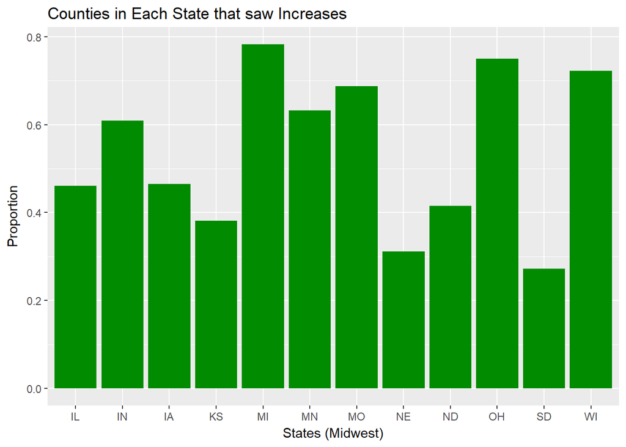

```r
Midwest_State <- rep(c("IL", "IN", "IA", "KS", "MI", "MN", "MO", "NE", "ND", "OH", "SD", "WI"))

Midwest_Proportion_Increased <- c(as.numeric(proportion_IL_up), as.numeric(proportion_IN_up), as.numeric(proportion_IA_up), as.numeric(proportion_KS_up), as.numeric(proportion_MI_up), as.numeric(proportion_MN_up), as.numeric(proportion_MO_up), as.numeric(proportion_NE_up), as.numeric(proportion_ND_up), as.numeric(proportion_OH_up), as.numeric(proportion_SD_up), as.numeric(proportion_WI_up))

Midwest_MktsMore <- data.frame(Midwest_State, Midwest_Proportion_Increased)

Midwest_MktsMore$Midwest_State <-factor(Midwest_MktsMore$Midwest_State,
                                levels = c("IL", "IN", "IA", "KS", "MI", "MN", "MO", "NE", "ND", "OH", "SD", "WI"))

Midwest_Mkts_Up <- ggplot (Midwest_MktsMore, aes(Midwest_State, Midwest_Proportion_Increased))
Midwest_Mkts_Up + geom_bar(stat = "identity",fill="green4") + xlab("States (Midwest)") + ylab("Proportion") + ggtitle("Counties in Each State that saw Increases")
```

#### Here are the proportions of counties in each Northeastern state that saw increases from 2009 to 2016. All states had more than half their counties see increases; four states had all counties see increases, as had Washington, DC.

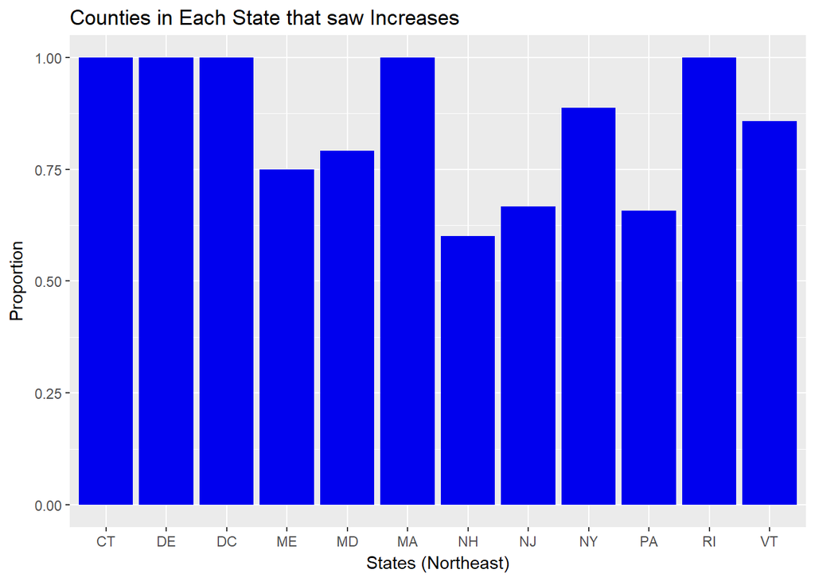

```r
Northeast_State <- rep(c("CT", "DE", "DC", "ME", "MD", "MA", "NH", "NJ", "NY", "PA", "RI", "VT"))

Northeast_Proportion_Increased <- c(as.numeric(proportion_CT_up), as.numeric(proportion_DC_up), as.numeric(proportion_DE_up), as.numeric(proportion_ME_up), as.numeric(proportion_MD_up), as.numeric(proportion_MA_up), as.numeric(proportion_NH_up), as.numeric(proportion_NJ_up), as.numeric(proportion_NY_up), as.numeric(proportion_PA_up), as.numeric(proportion_RI_up), as.numeric(proportion_VT_up))

Northeast_MktsMore <- data.frame(Northeast_State, Northeast_Proportion_Increased)

Northeast_MktsMore$Northeast_State <-factor(Northeast_MktsMore$Northeast_State,
                                  levels = c("CT", "DE", "DC", "ME", "MD", "MA", "NH", "NJ", "NY", "PA", "RI", "VT"))

Northeast_Mkts_Up <- ggplot (Northeast_MktsMore, aes(Northeast_State, Northeast_Proportion_Increased))
Northeast_Mkts_Up + geom_bar(stat = "identity",fill="blue2") + xlab("States (Northeast)") + ylab("Proportion") + ggtitle("Counties in Each State that saw Increases")
```

#### Here are the proportions of counties in each Southern state that saw increases from 2009 to 2016. The majority of states had less than half their counties see increases.

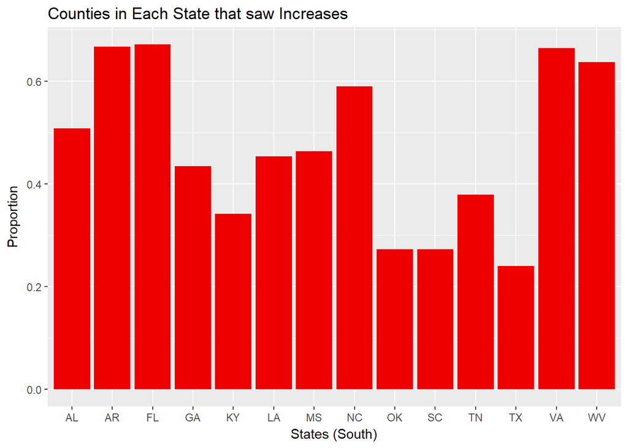

```r
South_State <- rep(c("AL", "AR", "FL", "GA", "KY", "LA", "MS", "NC", "OK", "SC", "TN", "TX", "VA", "WV"))

South_Proportion_Increased <- c(as.numeric(proportion_AL_up), as.numeric(proportion_AR_up), as.numeric(proportion_FL_up), as.numeric(proportion_GA_up), as.numeric(proportion_KY_up), as.numeric(proportion_LA_up), as.numeric(proportion_MS_up), as.numeric(proportion_NC_up), as.numeric(proportion_OK_up), as.numeric(proportion_SD_up), as.numeric(proportion_TN_up), as.numeric(proportion_TX_up), as.numeric(proportion_VA_up), as.numeric(proportion_WV_up))

South_MktsMore <- data.frame(South_State, South_Proportion_Increased)

South_MktsMore$State <-factor(South_MktsMore$South_State,
                              levels = c("AL", "AR", "FL", "GA", "KY", "LA", "MS", "NC", "OK", "SC", "TN", "TX", "VA", "WV"))

South_Mkts_Up <- ggplot (South_MktsMore, aes(South_State, South_Proportion_Increased))
South_Mkts_Up + geom_bar(stat = "identity",fill="red2") + xlab("States (South)") + ylab("Proportion") + ggtitle("Counties in Each State that saw Increases")
```

#### Here are the proportions of counties in each Western state that saw increases from 2009 to 2016. The majority of state had at least half their counties see an increase.

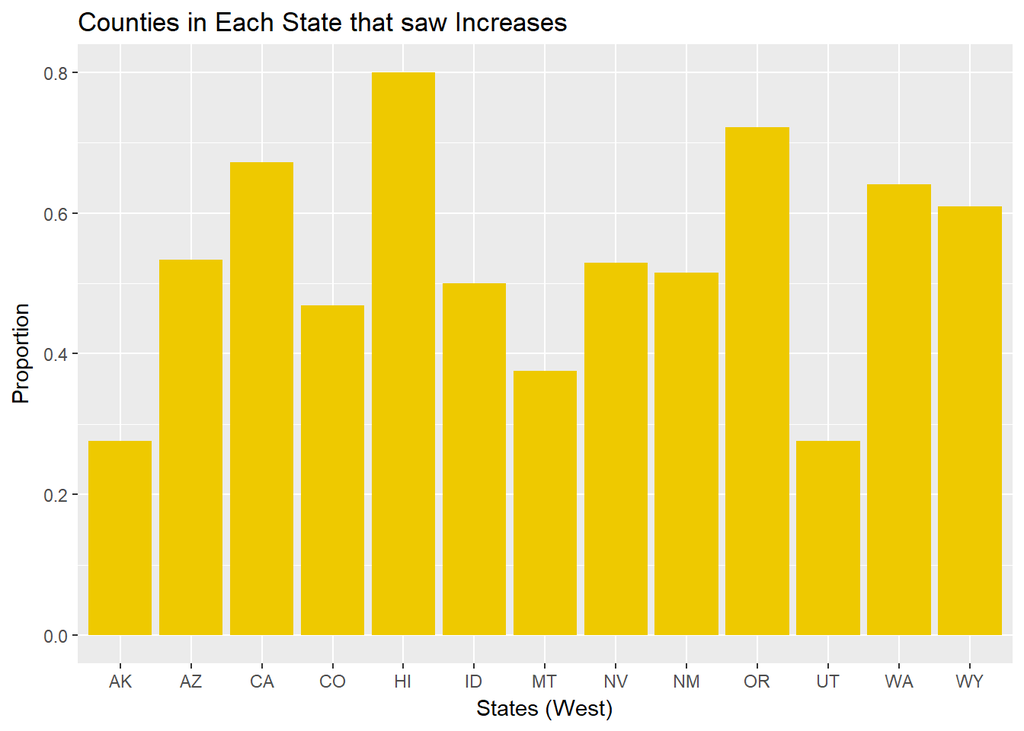

```r
West_State <- rep(c("AK", "AZ", "CA", "CO", "HI", "ID", "MT", "NV", "NM", "OR", "UT", "WA", "WY"))

West_Proportion_Increased <- c(as.numeric(proportion_AK_up), as.numeric(proportion_AZ_up), as.numeric(proportion_CA_up), as.numeric(proportion_CO_up), as.numeric(proportion_HI_up), as.numeric(proportion_ID_up), as.numeric(proportion_MT_up), as.numeric(proportion_NV_up), as.numeric(proportion_NM_up), as.numeric(proportion_OR_up), as.numeric(proportion_UT_up), as.numeric(proportion_WA_up), as.numeric(proportion_WY_up))

West_Mkts_More <- data.frame(West_State, West_Proportion_Increased)

West_Mkts_More$West_State <-factor(West_Mkts_More$West_State,
                        levels = c("AK", "AZ", "CA", "CO", "HI", "ID", "MT", "NV", "NM", "OR", "UT", "WA", "WY"))

West_Mkts_Up <- ggplot (West_Mkts_More, aes(West_State, West_Proportion_Increased))
West_Mkts_Up + geom_bar(stat = "identity",fill="gold2") + xlab("States (West)") + ylab("Proportion") + ggtitle("Counties in Each State that saw Increases")
```